# Bubble Detection and Dating in Fan Tokens

R analysis aligned with the submitted Phase 3 report

FRAM Group G07

# 1 Study scope

The submitted report uses daily token prices, returns, trading volume and Bitcoin, Ethereum and Chiliz benchmarks. It does not use Google Trends or a financial-stress index. The default R workflow follows its completed Phase 3 scope while retaining the original methodology paper’s R detection packages. The original repository and optional additional paper analyses remain included.

The primary sample ends on 30 June 2026, with an extension through 19 September 2026. Each cutoff is estimated independently. All 20 fan tokens and all three benchmarks retain their own first valid trading dates. Input prices are adjusted daily USD closes on a UTC calendar, with no forward-filling or winsorization.

The methodology chapter and completed Phase 3 use different specifications. The latter uses zero-lag regressions, approximate reference thresholds, a 30-day dating rule and a local-ADF Bayesian model. The default follows those choices; it does not claim the proposed bootstrap or hierarchical models were fitted. See `../Working-paper/Report-alignment.txt` for the comparison.

# 2 Libraries and execution

The core detection methods use the paper’s `exuber` 1.1.0 and `cpm` 2.3 packages. The Bayesian local-ADF extension is implemented in base R. JSON parsing uses `jsonlite`; file verification uses `digest`. No Python process is invoked.

```r
source("run_all.R")
```

The default render displays included outputs. Set `regenerate=TRUE` to execute the complete analysis while knitting, or run `Rscript run_all.R` first.

# 3 Data processing

`R/01_process_data.R` reconstructs daily data from all archived provider JSON responses, checks dates and duplicate prices, flags invalid observations and calculates adjacent-day log returns and 30-day volatility. The daily analysis snapshots are saved as `Processed-data/daily_panel_2026-06-30.csv` and `Processed-data/daily_panel_2026-09-19.csv`. Monthly/weekly datasets remain available for optional paper extensions and are not inputs to this daily run.

```r
knitr::kable(read_table(file.path(report_dir, "sample_comparison.csv")))
```

| cutoff_date | assets | fan_token_prices | gsadf_reference_exceedances | fan_persistent_intervals | ks_change_points_arl500 | fan_bayesian_days_ge95 |
| --- | --- | --- | --- | --- | --- | --- |
| 2026-06-30 | 23 | 37662 | 9 | 0 | 114 | 5 |
| 2026-09-19 | 23 | 39282 | 10 | 2 | 119 | 4 |

# 4 Recursive detection and episode dating

`exuber::radf()` is applied to daily log adjusted prices with an intercept and zero lagged differences. Its minimum-window argument counts regression rows; the reported PSY window counts price observations, so an explicit one-row conversion preserves the submitted estimation windows.

The original reference-table interpolation/extrapolation and SADF-based endpoint approximation are retained for comparison with Phase 3. These outputs are nominal reference classifications, not bootstrap p-values or matched BSADF simulated critical values. At least 30 consecutive daily exceedances are required for a retained interval. A statistical interval can accompany a price decline, so its price change is reported explicitly.

```r
t <- read_table(file.path(report_dir, "psy_test_summary.csv"))
knitr::kable(t[t$asset_type == "fan_token", c("cutoff_date", "symbol", "observations", "sadf_statistic", "gsadf_statistic", "gsadf_cv_95", "gsadf_reject_95", "longest95_run")], digits = 4)
```

|  | cutoff_date | symbol | observations | sadf_statistic | gsadf_statistic | gsadf_cv_95 | gsadf_reject_95 | longest95_run |
| --- | --- | --- | --- | --- | --- | --- | --- | --- |
| 4 | 2026-06-30 | VATRENI | 1312 | -0.7061 | 2.1706 | 2.3848 | FALSE | 2 |
| 5 | 2026-06-30 | OG | 2201 | 0.9293 | 6.0255 | 2.4626 | TRUE | 9 |
| 6 | 2026-06-30 | ATM | 2201 | 3.0975 | 5.0277 | 2.4626 | TRUE | 7 |
| 7 | 2026-06-30 | SANTOS | 1673 | -1.1444 | 2.1949 | 2.4164 | FALSE | 2 |
| 8 | 2026-06-30 | PSG | 2211 | 0.5837 | 4.1056 | 2.4635 | TRUE | 10 |
| 9 | 2026-06-30 | BAR | 2198 | 2.4852 | 3.9130 | 2.4623 | TRUE | 14 |
| 10 | 2026-06-30 | ASR | 2201 | 2.7383 | 4.5819 | 2.4626 | TRUE | 7 |
| 11 | 2026-06-30 | GAL | 2214 | 0.6086 | 4.6743 | 2.4637 | TRUE | 11 |
| 12 | 2026-06-30 | PORTO | 1688 | -0.4642 | 2.0525 | 2.4177 | FALSE | 3 |
| 13 | 2026-06-30 | CITY | 1862 | -0.4229 | 1.9584 | 2.4329 | FALSE | 2 |
| 14 | 2026-06-30 | LAZIO | 1714 | -1.9257 | 2.4050 | 2.4200 | FALSE | 3 |
| 15 | 2026-06-30 | JUV | 2261 | -0.3718 | 4.3533 | 2.4678 | TRUE | 3 |
| 16 | 2026-06-30 | ACM | 1954 | -0.6652 | 1.4270 | 2.4410 | FALSE | 0 |
| 17 | 2026-06-30 | AFC | 1707 | 0.1642 | 2.3975 | 2.4194 | FALSE | 10 |
| 18 | 2026-06-30 | ALPINE | 1591 | -1.2732 | 1.7661 | 2.4092 | FALSE | 2 |
| 19 | 2026-06-30 | INTER | 1751 | 1.5695 | 3.2155 | 2.4232 | TRUE | 5 |
| 20 | 2026-06-30 | TRA | 2059 | -0.5083 | 2.2895 | 2.4502 | FALSE | 3 |
| 21 | 2026-06-30 | ARG | 1786 | -0.6426 | 2.2373 | 2.4263 | FALSE | 3 |
| 22 | 2026-06-30 | NAP | 1398 | 0.8082 | 2.3117 | 2.3923 | FALSE | 2 |
| 23 | 2026-06-30 | POR | 1680 | 2.6604 | 3.8473 | 2.4170 | TRUE | 22 |
| 27 | 2026-09-19 | VATRENI | 1393 | -0.7061 | 2.1706 | 2.3919 | FALSE | 2 |
| 28 | 2026-09-19 | OG | 2282 | 0.9293 | 6.0219 | 2.4697 | TRUE | 9 |
| 29 | 2026-09-19 | ATM | 2282 | 3.0975 | 4.9109 | 2.4697 | TRUE | 7 |
| 30 | 2026-09-19 | SANTOS | 1754 | -1.1444 | 2.0437 | 2.4235 | FALSE | 2 |
| 31 | 2026-09-19 | PSG | 2292 | 0.5837 | 4.1056 | 2.4705 | TRUE | 10 |
| 32 | 2026-09-19 | BAR | 2279 | 2.4852 | 3.8772 | 2.4694 | TRUE | 14 |
| 33 | 2026-09-19 | ASR | 2282 | 2.7383 | 4.4620 | 2.4697 | TRUE | 7 |
| 34 | 2026-09-19 | GAL | 2295 | 0.6086 | 4.6743 | 2.4708 | TRUE | 11 |
| 35 | 2026-09-19 | PORTO | 1769 | -0.4642 | 2.0368 | 2.4248 | FALSE | 3 |
| 36 | 2026-09-19 | CITY | 1943 | -0.4229 | 1.9048 | 2.4400 | FALSE | 2 |
| 37 | 2026-09-19 | LAZIO | 1795 | -1.9257 | 2.3707 | 2.4271 | FALSE | 3 |
| 38 | 2026-09-19 | JUV | 2342 | -0.3420 | 4.2435 | 2.4749 | TRUE | 3 |
| 39 | 2026-09-19 | ACM | 2035 | -0.6132 | 1.3326 | 2.4481 | FALSE | 0 |
| 40 | 2026-09-19 | AFC | 1788 | -0.1406 | 2.3819 | 2.4264 | FALSE | 10 |
| 41 | 2026-09-19 | ALPINE | 1672 | -1.2732 | 1.7661 | 2.4163 | FALSE | 2 |
| 42 | 2026-09-19 | INTER | 1832 | 1.5695 | 3.2155 | 2.4303 | TRUE | 5 |
| 43 | 2026-09-19 | TRA | 2140 | -0.5083 | 2.1814 | 2.4573 | FALSE | 3 |
| 44 | 2026-09-19 | ARG | 1867 | -0.3773 | 2.8553 | 2.4334 | TRUE | 34 |
| 45 | 2026-09-19 | NAP | 1479 | 0.8082 | 2.1998 | 2.3994 | FALSE | 2 |
| 46 | 2026-09-19 | POR | 1761 | 2.6604 | 5.7221 | 2.4241 | TRUE | 97 |

```r
knitr::kable(read_table(file.path(report_dir, "psy_persistent_intervals.csv")), digits = 4)
```

| cutoff_date | asset_id | symbol | asset_type | block | start_date | end_date | peak_bsadf_date | duration_days | peak_bsadf | price_change_pct | ongoing | interpretation |
| --- | --- | --- | --- | --- | --- | --- | --- | --- | --- | --- | --- | --- |
| 2026-06-30 | chiliz | CHZ | benchmark | 1 | 2021-03-02 | 2021-04-23 | 2021-03-12 | 53 | 8.1436 | 555.8731 | FALSE | persistent reference-threshold signal; inspect price direction |
| 2026-09-19 | chiliz | CHZ | benchmark | 1 | 2021-03-02 | 2021-04-23 | 2021-03-12 | 53 | 8.1436 | 555.8731 | FALSE | persistent reference-threshold signal; inspect price direction |
| 2026-09-19 | argentine-football-association-fan-token | ARG | fan_token | 1 | 2026-07-21 | 2026-08-23 | 2026-07-30 | 34 | 2.5828 | -44.1715 | FALSE | persistent reference-threshold signal; inspect price direction |
| 2026-09-19 | portugal-national-team-fan-token | POR | fan_token | 1 | 2026-06-15 | 2026-09-19 | 2026-07-14 | 97 | 5.7221 | -69.8902 | TRUE | persistent reference-threshold signal; inspect price direction |

# 5 Sequential distribution changes

The methodology paper’s actual `cpm::processStream()` Kolmogorov-Smirnov model is applied to daily log returns. Startup uses 20% of the valid return sample, rounded upward, with a minimum of 30 observations. ARL0 is 500, with 1000 as a sensitivity check. Estimated change dates and subsequent detection dates are exported separately.

This preserves the paper’s nonparametric sequential method. The submitted Phase 3 instead used penalized segmentation of mean and log squared returns. Their change counts differ; the submitted 76.8% volatility-shift result is not recomputed or attributed to KS-CPM.

```r
knitr::kable(read_table(file.path(report_dir, "ks_cpm_change_points.csv")))
```

| cutoff_date | asset_id | symbol | asset_type | block | arl0 | startup_return_observations | change_point_date | first_post_change_date | detection_date |
| --- | --- | --- | --- | --- | --- | --- | --- | --- | --- |
| 2026-06-30 | bitcoin | BTC | benchmark | 1 | 500 | 548 | 2020-07-20 | 2020-07-21 | 2020-12-29 |
| 2026-06-30 | bitcoin | BTC | benchmark | 1 | 500 | 548 | 2021-01-08 | 2021-01-09 | 2022-01-19 |
| 2026-06-30 | bitcoin | BTC | benchmark | 1 | 500 | 548 | 2022-07-12 | 2022-07-13 | 2023-01-11 |
| 2026-06-30 | bitcoin | BTC | benchmark | 1 | 500 | 548 | 2022-11-13 | 2022-11-14 | 2024-01-11 |
| 2026-06-30 | bitcoin | BTC | benchmark | 1 | 500 | 548 | 2024-03-13 | 2024-03-14 | 2024-06-28 |
| 2026-06-30 | bitcoin | BTC | benchmark | 1 | 1000 | 548 | 2020-07-20 | 2020-07-21 | 2021-01-03 |
| 2026-06-30 | bitcoin | BTC | benchmark | 1 | 1000 | 548 | 2021-01-08 | 2021-01-09 | 2022-01-19 |
| 2026-06-30 | bitcoin | BTC | benchmark | 1 | 1000 | 548 | 2022-12-28 | 2022-12-29 | 2023-01-17 |
| 2026-06-30 | bitcoin | BTC | benchmark | 1 | 1000 | 548 | 2024-03-13 | 2024-03-14 | 2024-07-04 |
| 2026-06-30 | ethereum | ETH | benchmark | 1 | 500 | 548 | 2020-07-20 | 2020-07-21 | 2020-07-27 |
| 2026-06-30 | ethereum | ETH | benchmark | 1 | 500 | 548 | 2021-11-02 | 2021-11-03 | 2022-04-24 |
| 2026-06-30 | ethereum | ETH | benchmark | 1 | 500 | 548 | 2022-09-21 | 2022-09-22 | 2023-05-04 |
| 2026-06-30 | ethereum | ETH | benchmark | 1 | 500 | 548 | 2024-11-05 | 2024-11-06 | 2024-11-10 |
| 2026-06-30 | ethereum | ETH | benchmark | 1 | 1000 | 548 | 2021-01-01 | 2021-01-02 | 2021-01-05 |
| 2026-06-30 | ethereum | ETH | benchmark | 1 | 1000 | 548 | 2021-10-29 | 2021-10-30 | 2022-07-03 |
| 2026-06-30 | ethereum | ETH | benchmark | 1 | 1000 | 548 | 2022-09-21 | 2022-09-22 | 2023-05-29 |
| 2026-06-30 | ethereum | ETH | benchmark | 1 | 1000 | 548 | 2024-11-05 | 2024-11-06 | 2024-11-11 |
| 2026-06-30 | chiliz | CHZ | benchmark | 1 | 500 | 512 | 2019-12-17 | 2019-12-18 | 2020-11-24 |
| 2026-06-30 | chiliz | CHZ | benchmark | 1 | 500 | 512 | 2020-12-18 | 2020-12-19 | 2021-05-12 |
| 2026-06-30 | chiliz | CHZ | benchmark | 1 | 500 | 512 | 2021-03-18 | 2021-03-19 | 2022-05-14 |
| 2026-06-30 | chiliz | CHZ | benchmark | 1 | 500 | 512 | 2022-08-13 | 2022-08-14 | 2022-08-17 |
| 2026-06-30 | chiliz | CHZ | benchmark | 1 | 500 | 512 | 2023-10-15 | 2023-10-16 | 2024-03-26 |
| 2026-06-30 | chiliz | CHZ | benchmark | 1 | 1000 | 512 | 2019-12-17 | 2019-12-18 | 2020-11-24 |
| 2026-06-30 | chiliz | CHZ | benchmark | 1 | 1000 | 512 | 2020-12-18 | 2020-12-19 | 2021-05-12 |
| 2026-06-30 | chiliz | CHZ | benchmark | 1 | 1000 | 512 | 2021-03-18 | 2021-03-19 | 2022-05-14 |
| 2026-06-30 | chiliz | CHZ | benchmark | 1 | 1000 | 512 | 2023-04-25 | 2023-04-26 | 2023-05-26 |
| 2026-06-30 | chiliz | CHZ | benchmark | 1 | 1000 | 512 | 2023-10-17 | 2023-10-18 | 2024-09-18 |
| 2026-06-30 | croatian-ff-fan-token | VATRENI | fan_token | 1 | 500 | 263 | 2023-06-28 | 2023-06-29 | 2023-08-26 |
| 2026-06-30 | croatian-ff-fan-token | VATRENI | fan_token | 1 | 500 | 263 | 2023-11-16 | 2023-11-17 | 2024-03-17 |
| 2026-06-30 | croatian-ff-fan-token | VATRENI | fan_token | 1 | 500 | 263 | 2024-06-13 | 2024-06-14 | 2024-08-05 |

[output cut: 408 more lines]

# 6 Bayesian diagnostics and benchmark comparisons

The local-ADF model actually used in Phase 3 is ported to base R: normal coefficient priors, slope-prior standard deviation 0.5, standardized innovation variance fixed at one and expected run length 365 days. It exports reset and positive-slope probabilities. Full-sample scaling is retrospective within each cutoff. It is distinct from both the paper’s BSTS forecasts and the methodology chapter’s proposed normal-inverse-gamma return model.

Daily return correlations compare every fan token against BTC, ETH and CHZ. They describe co-movement and do not establish causality.

```r
knitr::kable(read_table(file.path(report_dir, "benchmark_return_correlations.csv")), digits = 4)
```

| cutoff_date | asset_id | benchmark | matched_returns | correlation |
| --- | --- | --- | --- | --- |
| 2026-06-30 | croatian-ff-fan-token | bitcoin | 1311 | 0.1114 |
| 2026-06-30 | croatian-ff-fan-token | ethereum | 1311 | 0.0832 |
| 2026-06-30 | croatian-ff-fan-token | chiliz | 1311 | 0.1103 |
| 2026-06-30 | og-fan-token | bitcoin | 2200 | 0.2591 |
| 2026-06-30 | og-fan-token | ethereum | 2200 | 0.2765 |
| 2026-06-30 | og-fan-token | chiliz | 2200 | 0.3643 |
| 2026-06-30 | atletico-madrid | bitcoin | 2200 | 0.3030 |
| 2026-06-30 | atletico-madrid | ethereum | 2200 | 0.3335 |
| 2026-06-30 | atletico-madrid | chiliz | 2200 | 0.4281 |
| 2026-06-30 | santos-fc-fan-token | bitcoin | 1672 | 0.3185 |
| 2026-06-30 | santos-fc-fan-token | ethereum | 1672 | 0.3487 |
| 2026-06-30 | santos-fc-fan-token | chiliz | 1672 | 0.4941 |
| 2026-06-30 | paris-saint-germain-fan-token | bitcoin | 2210 | 0.3333 |
| 2026-06-30 | paris-saint-germain-fan-token | ethereum | 2210 | 0.3502 |
| 2026-06-30 | paris-saint-germain-fan-token | chiliz | 2210 | 0.4207 |
| 2026-06-30 | fc-barcelona-fan-token | bitcoin | 2197 | 0.3786 |
| 2026-06-30 | fc-barcelona-fan-token | ethereum | 2197 | 0.4092 |
| 2026-06-30 | fc-barcelona-fan-token | chiliz | 2197 | 0.5546 |
| 2026-06-30 | as-roma-fan-token | bitcoin | 2200 | 0.3106 |
| 2026-06-30 | as-roma-fan-token | ethereum | 2200 | 0.3417 |
| 2026-06-30 | as-roma-fan-token | chiliz | 2200 | 0.4328 |
| 2026-06-30 | galatasaray-fan-token | bitcoin | 2213 | 0.2648 |
| 2026-06-30 | galatasaray-fan-token | ethereum | 2213 | 0.3152 |
| 2026-06-30 | galatasaray-fan-token | chiliz | 2213 | 0.3476 |
| 2026-06-30 | fc-porto | bitcoin | 1687 | 0.4069 |
| 2026-06-30 | fc-porto | ethereum | 1687 | 0.4460 |
| 2026-06-30 | fc-porto | chiliz | 1687 | 0.5715 |
| 2026-06-30 | manchester-city-fan-token | bitcoin | 1861 | 0.3849 |
| 2026-06-30 | manchester-city-fan-token | ethereum | 1861 | 0.4264 |
| 2026-06-30 | manchester-city-fan-token | chiliz | 1861 | 0.5247 |

[output cut: 90 more lines]

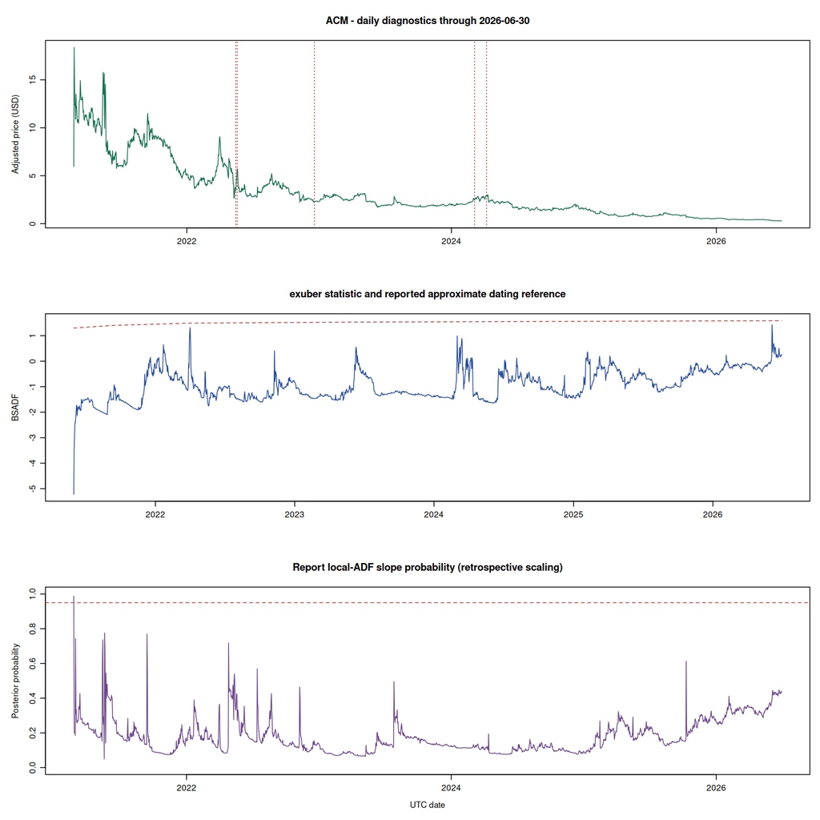

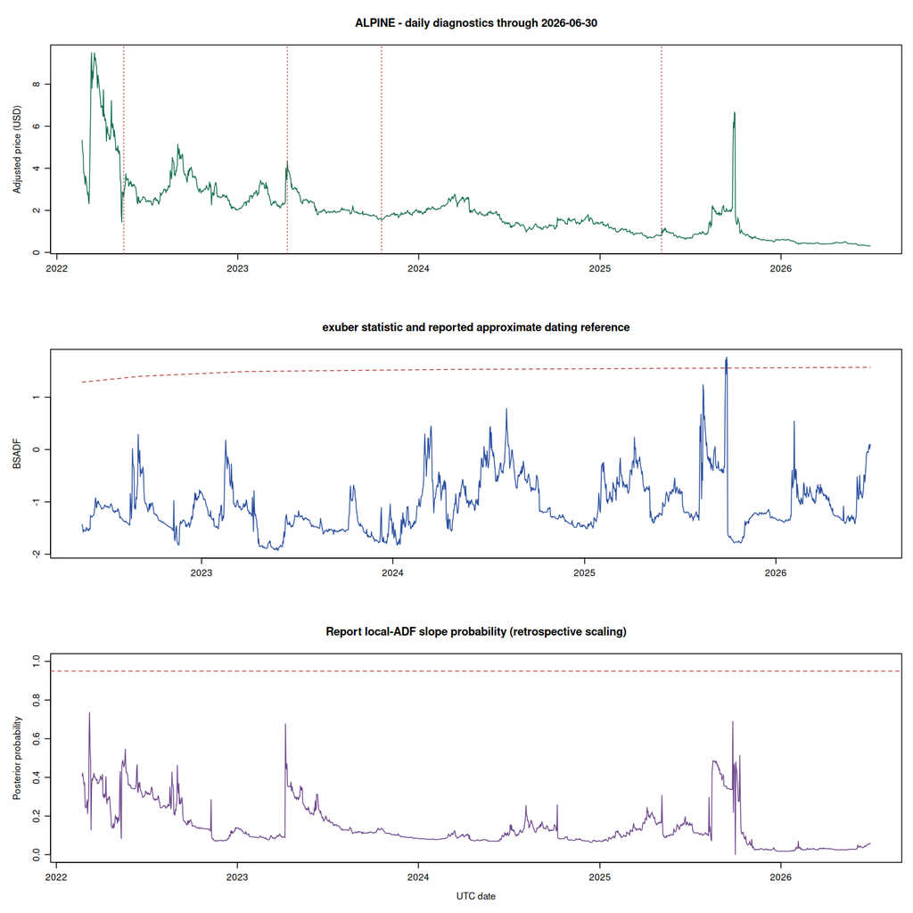

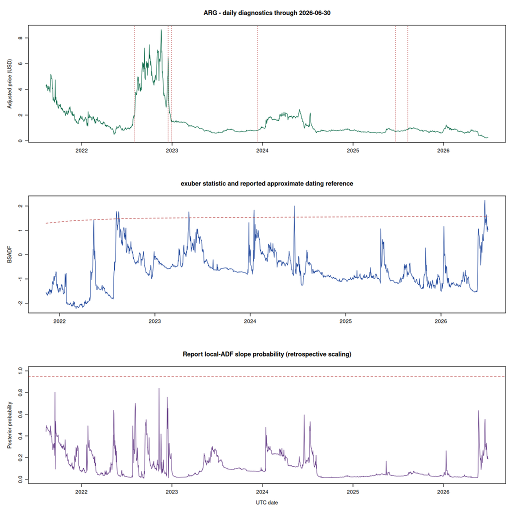

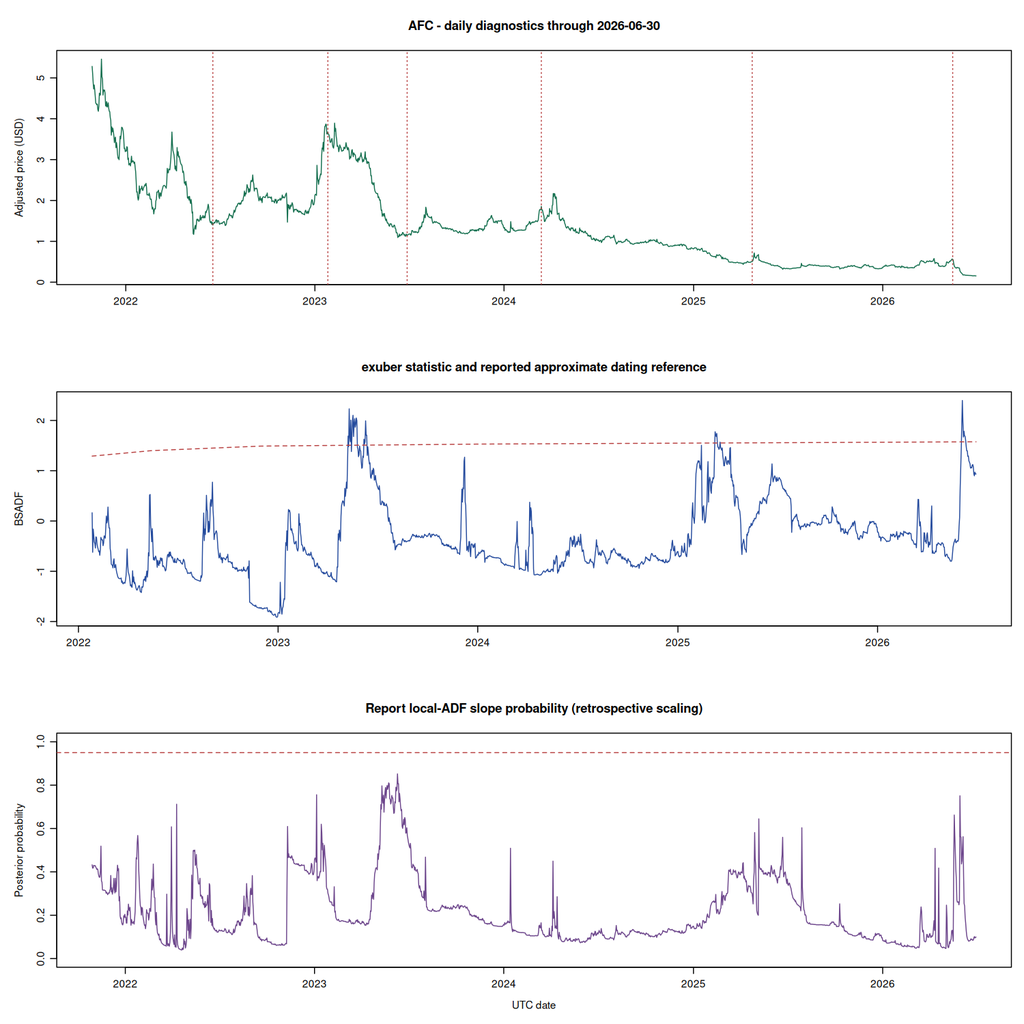

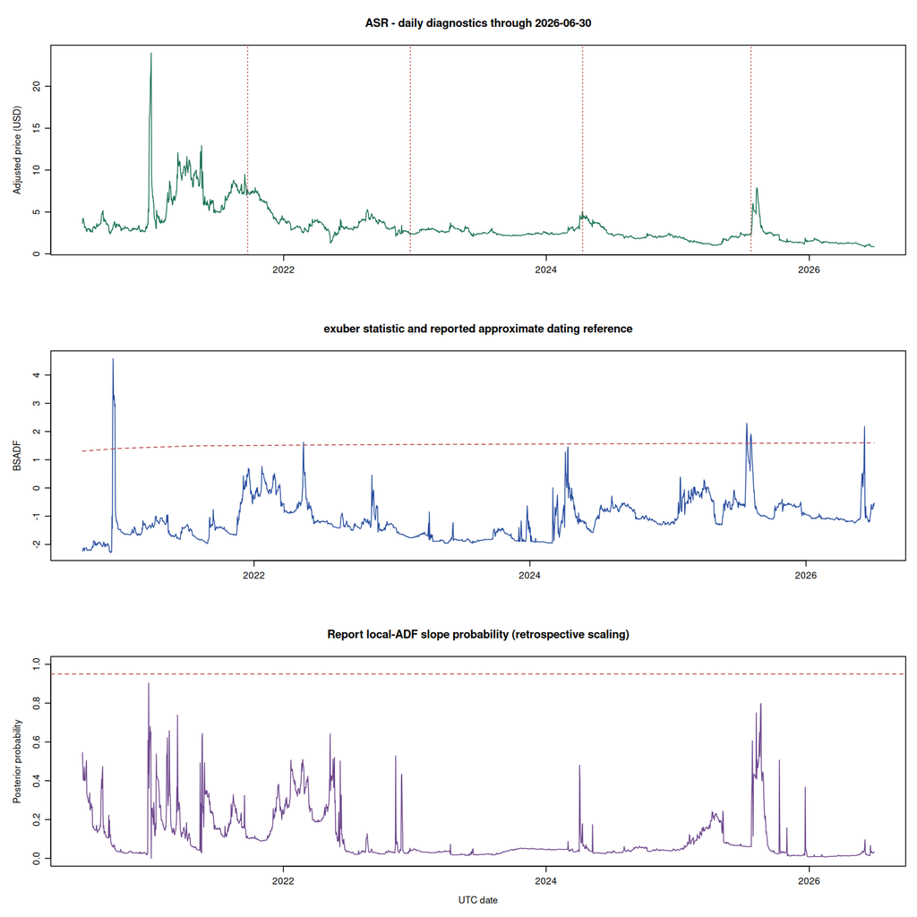

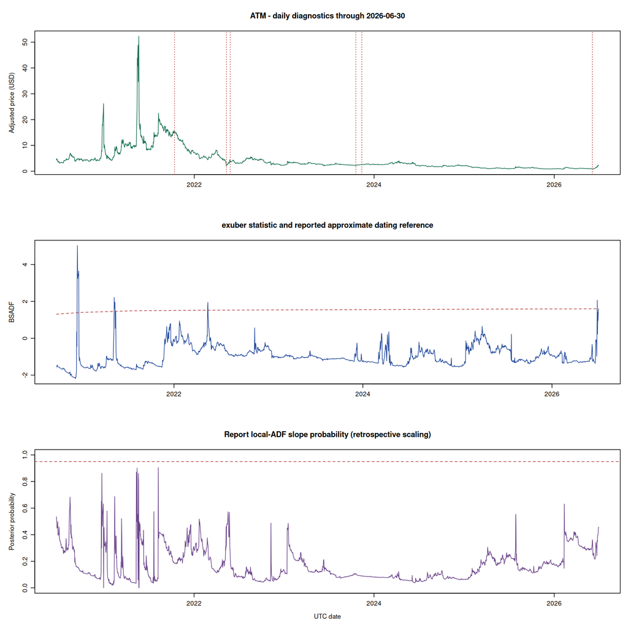

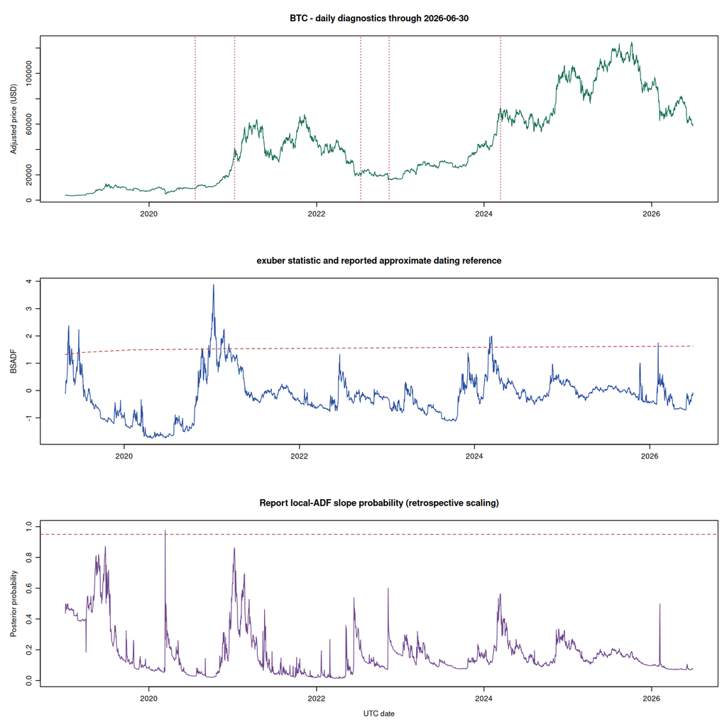

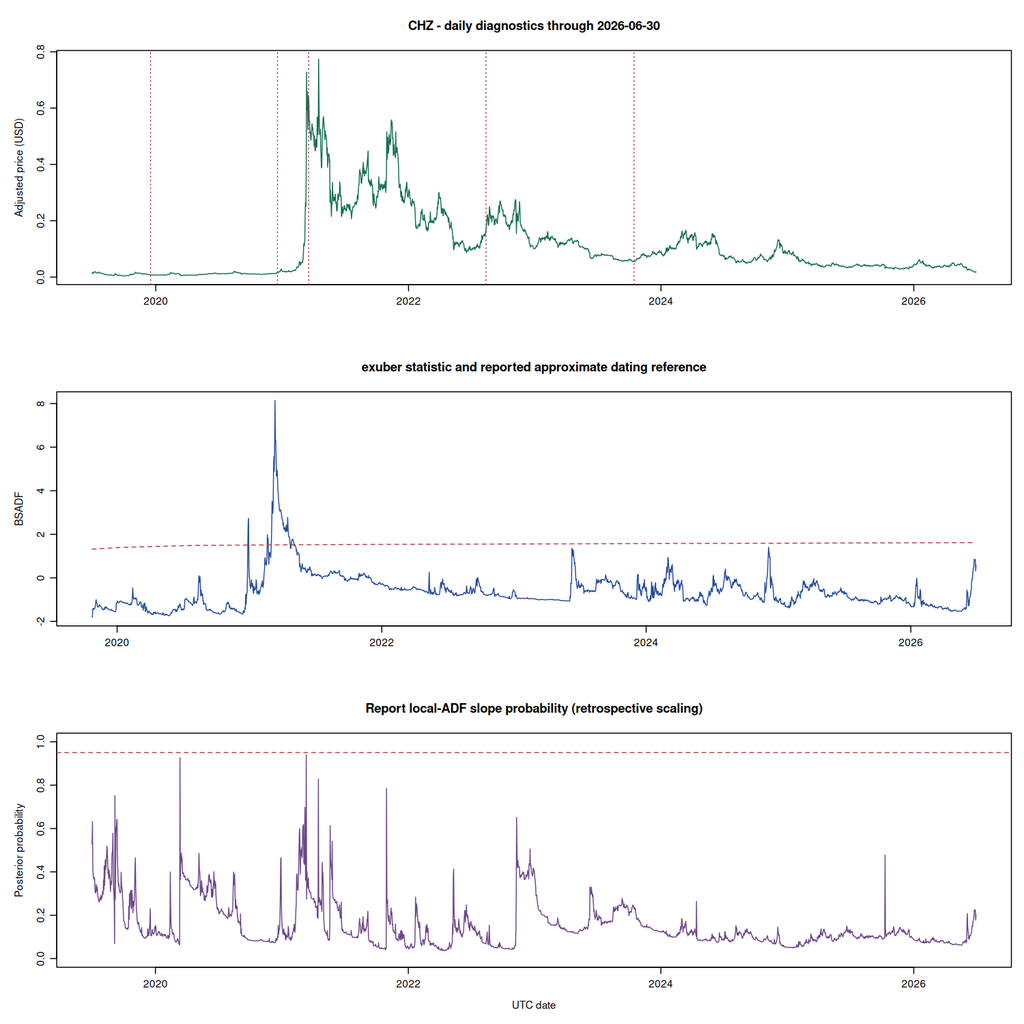

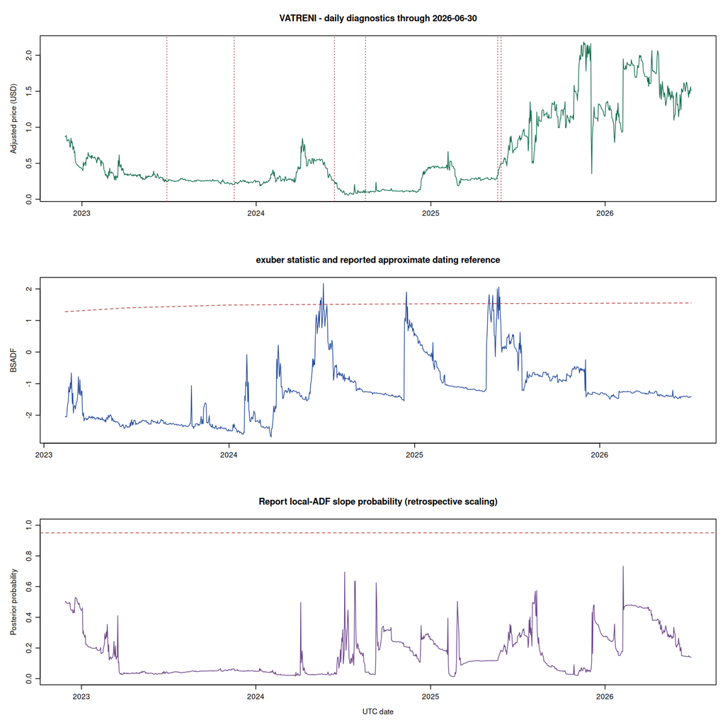

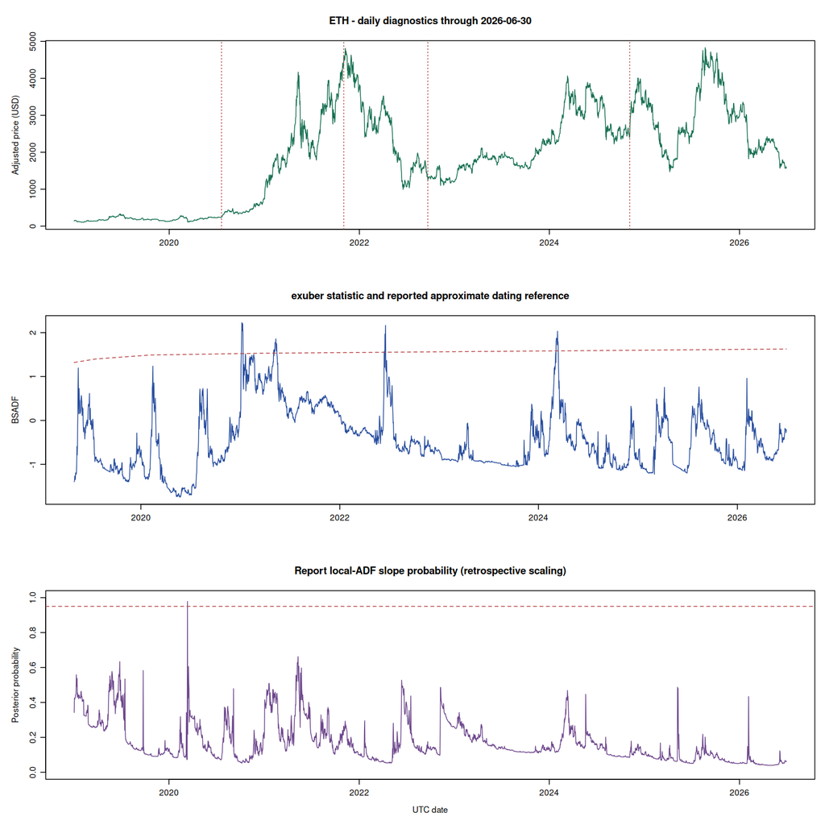

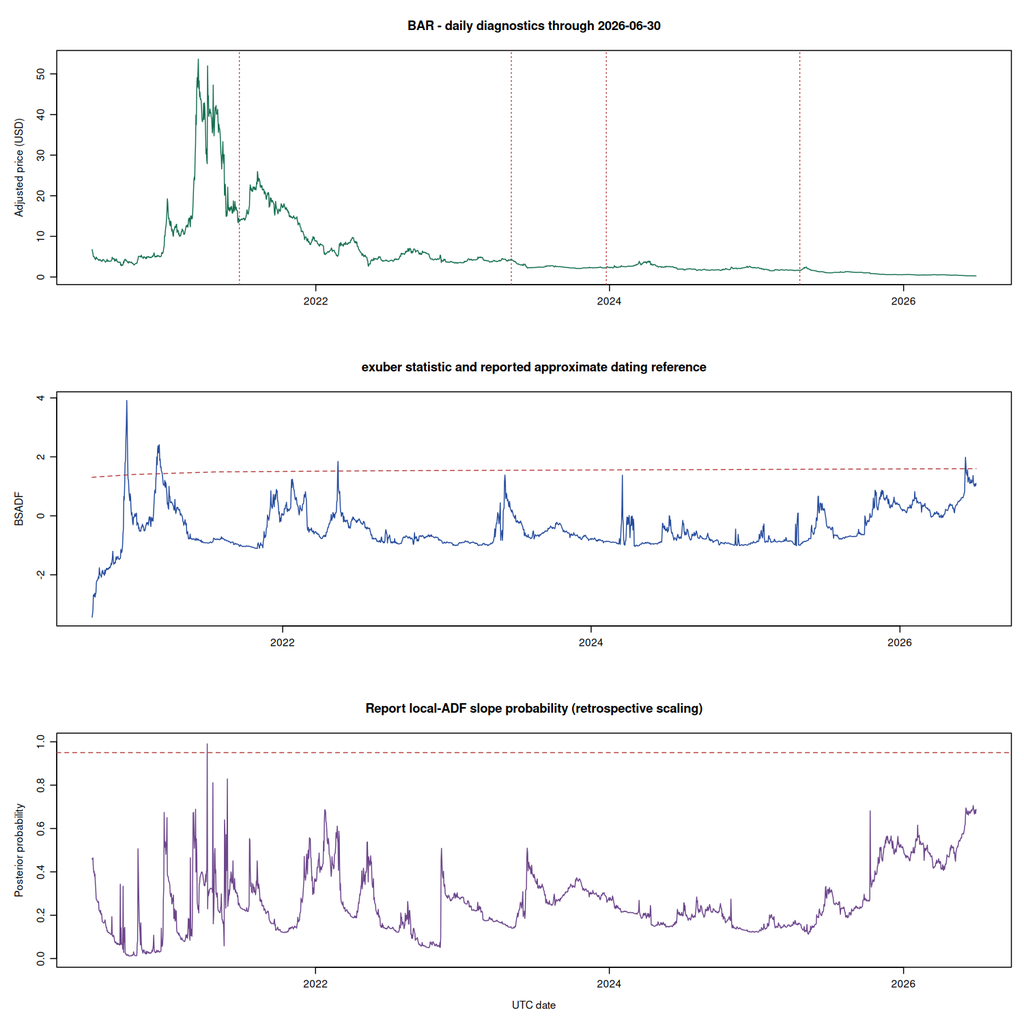

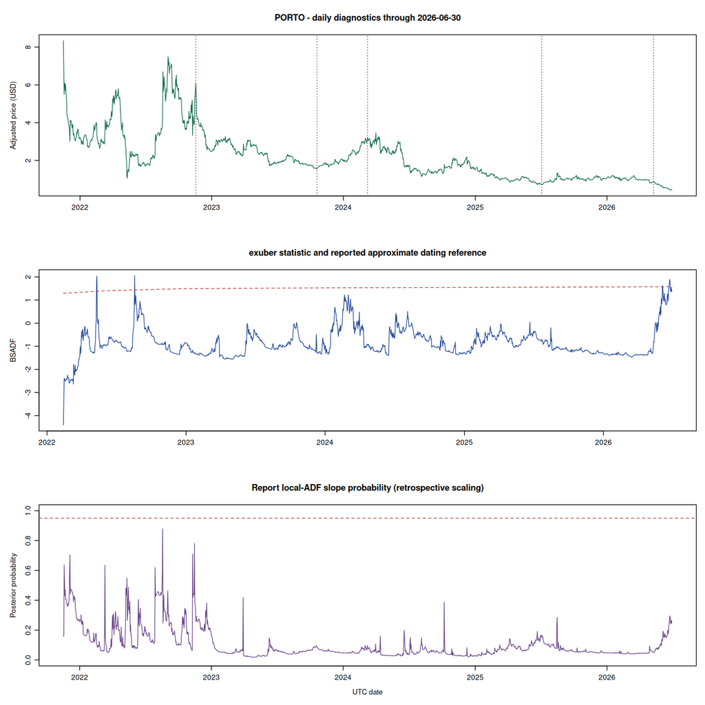

[34 more figures not shown]

# 7 Results and verification

```
FAN-TOKEN R RESULTS ALIGNED WITH THE SUBMITTED PHASE 3 SCOPE

Daily log adjusted USD prices; 20 fan tokens plus BTC/ETH/CHZ.
Primary cutoff 2026-06-30; extension cutoff 2026-09-19; 30 consecutive days for retained intervals.

 cutoff_date assets fan_token_prices gsadf_reference_exceedances
  2026-06-30     23            37662                           9
  2026-09-19     23            39282                          10
 fan_persistent_intervals ks_change_points_arl500 fan_bayesian_days_ge95
                        0                     114                      5
                        2                     119                      4

The report does not use Google Trends or a financial-stress index. These are outside its scope.
The R workflow retains exuber::radf and cpm::processStream from the methodology paper.
The submitted reference-table interpolation and SADF-based dating approximation are retained for comparability.
These are nominal reference classifications, not bootstrap p-values or matched BSADF critical values.
Daily Bayesian local-ADF probabilities follow the submitted Phase 3 model and use retrospective full-sample scaling.
KS-CPM replaces the submitted penalized mean-shift segmentation to preserve the paper's core method.
Its counts must not be read as reproducing the report's 76.8% volatility-shift statistic.
Proposed BIC/wild-bootstrap/NIG/hierarchical extensions are not claimed as implemented results.
ARIMA/BSTS, Johansen/VECM and monthly/weekly analyses are preserved as optional paper extensions.
See Working-paper/Report-alignment.txt for the complete scope comparison.

162 checks passed.
```

Validation compares the R recursive statistics, original sample counts, persistent intervals and local-ADF probabilities against the archived outputs underlying the submission. KS-CPM is checked as its own model and is not forced to reproduce penalized-segmentation counts. Raw inputs and the submitted Word document are retained unchanged.

```r
knitr::kable(read_table("Results/method_status.csv"))
```

| section | status | detail |
| --- | --- | --- |
| Daily log-price SADF/GSADF and BSADF | COMPLETED | exuber statistics; submitted Phase 3 approximate reference thresholds retained and labeled |
| 30-day persistence and June/September comparison | COMPLETED | Both cutoffs re-estimated independently; adjusted USD prices; all 23 assets |
| Daily sequential KS-CPM | COMPLETED | Paper cpm algorithm retained; differs from submitted Phase 3 penalized mean segmentation |
| Reported local-ADF Bayesian diagnostics | COMPLETED | Base-R port of submitted local normal-prior model; not BSTS or proposed NIG model |
| BTC/ETH/CHZ comparisons | COMPLETED | Daily return correlations; ETH is retained alongside BTC and CHZ |
| Google Trends and financial stress | OUTSIDE_SUBMITTED_REPORT_SCOPE | Not required inputs and not missing project tasks |
| ARIMA/BSTS forecasting and Johansen/VECM | OPTIONAL_PAPER_EXTENSIONS | Preserved separately; run_paper_extensions.R, not part of the submitted results |
| Wild bootstrap and hierarchical logit | PROPOSED_NOT_REPORTED_AS_IMPLEMENTED | Discussed in methodology; Phase 3 uses reference tables/local ADF and calls pooling future work |

# 8 Optional original paper extensions

`run_paper_extensions.R` and `Paper-extensions.Rmd` preserve the earlier monthly and weekly paper profile, ARIMA/BSTS forecasting and benchmark Johansen/VECM. Those results remain separate from this submitted-report analysis. Google Trends, sentiment density analysis and financial-stress propagation belong to additional original-paper sections; they are outside this project’s submitted empirical scope. The complete original R source is in `../Original-paper/`.